# California Housing Price Prediction: A case study

## 7.5 Smoothing Spline

**Theoretical basis** Smoothing splines minimise the penalised RSS:

$$\sum_{i=1}^{n}(y_i - g(x_i))^2 + \lambda
\int g''(t)^2 \, dt$$

- The tuning parameter $\lambda$ controls the bias-variance trade-off. Large $\lambda$ → smooth $g$; $\lambda \to 0$ → interpolates the data. $\lambda$ is selected automatically via **REML** cross-validation when using `mgcv::gam()`.
- We began by investigating how it works on one variable.

```r
ss_model_1d <- mgcv::gam(
  median_house_value ~ s(median_income, k = 10, bs = "cr"),  # cubic regression spline
  data   = train_sc,
  method = "REML"
)

summary(ss_model_1d)
```

```
#>
#> Family: gaussian
#> Link function: identity
#>
#> Formula:
#> median_house_value ~ s(median_income, k = 10, bs = "cr")
#>
#> Parametric coefficients:
#>             Estimate Std. Error t value Pr(>|t|)
#> (Intercept) 189178.6      617.7   306.2   <2e-16 ***
#> ---
#> Signif. codes:  0 '***' 0.001 '**' 0.01 '*' 0.05 '.' 0.1 ' ' 1
#>
#> Approximate significance of smooth terms:
#>                   edf Ref.df    F p-value
#> s(median_income) 7.96  8.635 1248  <2e-16 ***
#> ---
#> Signif. codes:  0 '***' 0.001 '**' 0.01 '*' 0.05 '.' 0.1 ' ' 1
#>
#> R-sq.(adj) =  0.453   Deviance explained = 45.4%
#> -REML = 1.6342e+05  Scale est. = 4.957e+09  n = 12990
```

```r
cat("\nEffective df (median_income smooth):",
    round(sum(ss_model_1d$edf), 2), "\n")
```

```
#>
#> Effective df (median_income smooth): 8.96
```

```r
ss_1d_pred <- predict(ss_model_1d, newdata = test_sc)

ss_1d_metrics <- calc_metrics(actual = y_test, predicted = ss_1d_pred, model_name = "Single Smoothing Spline")
all_metrics[["SSpline_1D"]] <- ss_1d_metrics
all_preds[["SSpline_1D"]] <- ss_1d_pred

print(ss_1d_metrics)
```

```
#> # A tibble: 1 × 4
#>   Model                     RMSE    MAE    R2
#>   <chr>                    <dbl>  <dbl> <dbl>
#> 1 Single Smoothing Spline 71924. 54790. 0.435
```

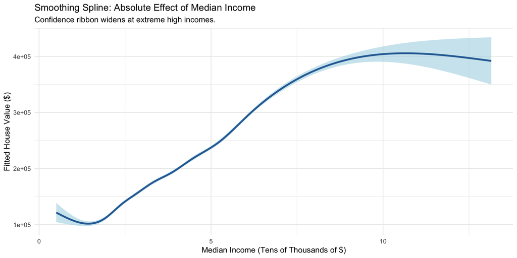

```r
grid_df_1d <- data.frame(
  median_income = seq(min(train_sc$median_income), max(train_sc$median_income), length = 300)
)

gam_preds <- predict(ss_model_1d, newdata = grid_df_1d, se.fit = TRUE)
grid_df_1d$fitted <- gam_preds$fit
grid_df_1d$se     <- gam_preds$se.fit

grid_df_1d$income_orig <- as.numeric(
  (grid_df_1d$median_income * preproc_all$std["median_income"]) +
  preproc_all$mean["median_income"]
)

ggplot(grid_df_1d, aes(x = income_orig, y = fitted)) +
  geom_ribbon(aes(ymin = fitted - 1.96 * se, ymax = fitted + 1.96 * se),
              fill = "lightblue", alpha = 0.6) +
  geom_line(color = "#2e6da4", linewidth = 1.2) +
  labs(
    title    = "Smoothing Spline: Absolute Effect of Median Income",
    subtitle = "Confidence ribbon widens at extreme high incomes.",
    x        = "Median Income (Tens of Thousands of $)",
    y        = "Fitted House Value ($)"
  ) +
  theme_minimal()
```

```r
ss_multi <- mgcv::gam(
  median_house_value ~
    s(median_income,            k = 10, bs = "cr") +
    s(longitude,                k = 50, bs = "cr") +
    s(latitude,                 k = 50, bs = "cr") +
    s(housing_median_age,       k = 8,  bs = "cr") +
    s(rooms_per_household,      k = 8,  bs = "cr") +
    s(population_per_household, k = 8,  bs = "cr") +
    bedrooms_per_room,
  data   = train_sc,
  method = "REML"
)

summary(ss_multi)
```

```
#>
#> Family: gaussian
#> Link function: identity
#>
#> Formula:
#> median_house_value ~ s(median_income, k = 10, bs = "cr") + s(longitude,
#>     k = 50, bs = "cr") + s(latitude, k = 50, bs = "cr") + s(housing_median_age,
#>     k = 8, bs = "cr") + s(rooms_per_household, k = 8, bs = "cr") +
#>     s(population_per_household, k = 8, bs = "cr") + bedrooms_per_room
#>
#> Parametric coefficients:
#>                   Estimate Std. Error t value Pr(>|t|)
#> (Intercept)       189178.6      429.5  440.42   <2e-16 ***
#> bedrooms_per_room   1248.7     1273.9    0.98    0.327
#> ---
#> Signif. codes:  0 '***' 0.001 '**' 0.01 '*' 0.05 '.' 0.1 ' ' 1
#>
#> Approximate significance of smooth terms:
#>                                edf Ref.df       F p-value
#> s(median_income)             7.187  8.075 500.976 < 2e-16 ***
#> s(longitude)                44.975 48.010  95.504 < 2e-16 ***
#> s(latitude)                 44.022 47.580  85.270 < 2e-16 ***
#> s(housing_median_age)        3.804  4.639   5.712 6.8e-05 ***
#> s(rooms_per_household)       6.224  6.702  57.677 < 2e-16 ***
#> s(population_per_household)  6.739  6.960 356.903 < 2e-16 ***
#> ---
#> Signif. codes:  0 '***' 0.001 '**' 0.01 '*' 0.05 '.' 0.1 ' ' 1
#>
#> R-sq.(adj) =  0.736   Deviance explained = 73.8%
#> -REML = 1.5889e+05  Scale est. = 2.3968e+09  n = 12990
```

```r
ss_multi_pred <- predict(ss_multi, newdata = test_sc)

ss_multi_metrics <- calc_metrics(actual = y_test, predicted = ss_multi_pred, model_name = "Multi Smoothing Spline")
all_metrics[["SSpline_Multi"]] <- ss_multi_metrics
all_preds[["SSpline_Multi"]] <- ss_multi_pred

print(ss_multi_metrics)
```

```
#> # A tibble: 1 × 4
#>   Model                    RMSE   MAE    R2
#>   <chr>                   <dbl> <dbl> <dbl>
#> 1 Multi Smoothing Spline 50260. 35731 0.724
```

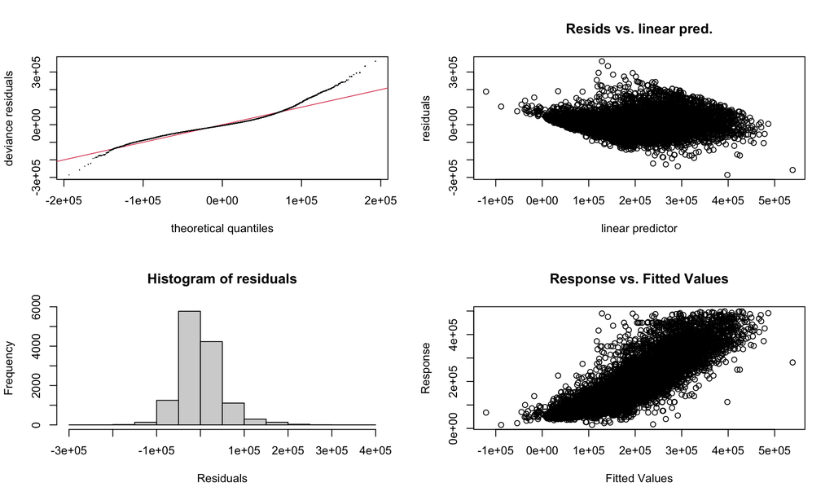

```
#>
#> Method: REML   Optimizer: outer newton
#> full convergence after 7 iterations.
#> Gradient range [-0.004221534,0.003512299]
#> (score 158892.3 & scale 2396759550).
#> Hessian positive definite, eigenvalue range [0.667462,6491.154].
#> Model rank =  130 / 130
#>
#> Basis dimension (k) checking results. Low p-value (k-index<1) may
#> indicate that k is too low, especially if edf is close to k'.
#>
#>                                k'   edf k-index p-value
#> s(median_income)             9.00  7.19    1.01    0.81
#> s(longitude)                49.00 44.97    0.95  <2e-16 ***
#> s(latitude)                 49.00 44.02    0.99    0.28
#> s(housing_median_age)        7.00  3.80    0.99    0.24
#> s(rooms_per_household)       7.00  6.22    0.98    0.05 *
#> s(population_per_household)  7.00  6.74    0.98    0.12
#> ---
#> Signif. codes:  0 '***' 0.001 '**' 0.01 '*' 0.05 '.' 0.1 ' ' 1
```

```r
# The mathematical audit for 'k' values
gam.check(ss_multi)
```

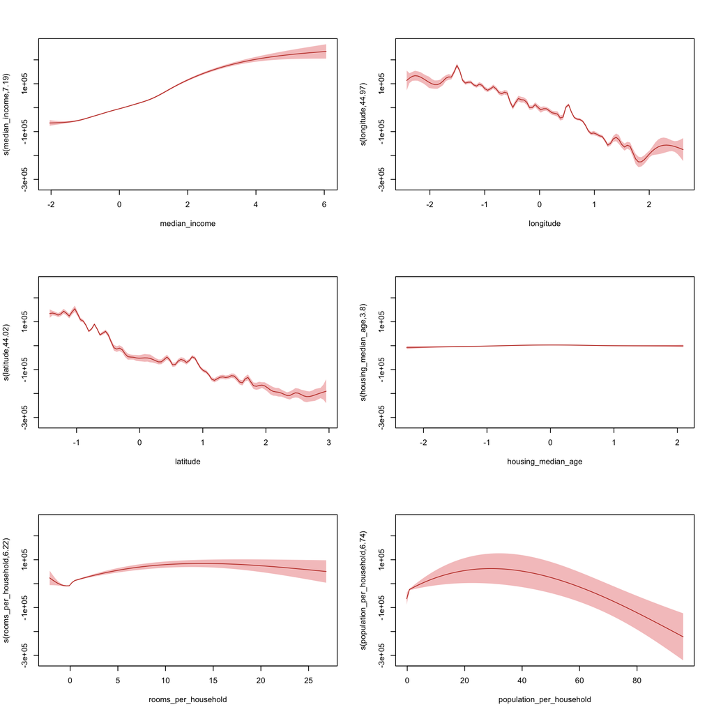

```r
par(mfrow = c(3, 2)) # 3x2 grid perfectly fits our 6 independent 1D variables

plot(ss_multi,
     pages = 0,
     shade = TRUE,
     col = "#c0392b",
     shade.col = "#f5c6c6",
     seWithMean = TRUE)
```

```r
par(mfrow = c(1, 1))
```

1. `median_income` -> As the median income increased (right of the x-axis), the house price also increased.
2. `housing_median_age` -> Once location and income are factored in, the median age of a house has relatively low effect to the house prices.
3. `rooms_per_household` -> The confidence intervals flared toward the right. This showed that at extreme values it was not a major driver of house prices.
4. `population_per_household` -> As the population increased, it started as a positive house price but in the long run became negative. This showed us that, overcrowded households tend to be in cheaper neighbourhoods where the house price is cheaper.